# Biostat 203B Homework 4

Due Mar 22 @ 11:59PM

Rui Xu

# Task

In this assignment, you are to write a report analyzing the electronic health record (EHR) data MIMIC-III. You report will demostrate your knowledge of working with PostgreSQL database, data visualization, and commonly used analytical methods such as logistic regression and neural network. Your report should include at least following parts:

1. An informative title. For example, *30-Day Mortality Rate of Myocardia Infarction Patients Admitted to CCU*.
2. Introduction. Describe the MIMIC-III data set and what research hypothesis/goal you are to address using this data.
3. Data preparation. Create a study cohort from MIMIC-III corresponding to your research hypothesis/goal. See the examplary code below. Use a CONSORT flow diagram to summarize your steps to create the cohort.
4. Data visualization. Use visualization to summarize the cohort you created.
5. Analytics. Use at least two analytical approaches to address your research hypothesis/goal. For example, we can use (1) logistic regression and (2) neural network to build a predictive model for the 30-day mortality rate of patients admitted into CCU and compare their predictive performance. Summarize your results in graphs.
6. Conclusions.

# Learning resources about analyzing EHR data

- *Secondary Analysis of Electronic Health Records*: https://link.springer.com/book/10.1007/978-3-319-43742-2
- *The Book of OHDSI*: https://ohdsi.github.io/TheBookOfOhdsi/.
- The GitHub repository https://github.com/MIT-LCP/mimic-code contains some code examples for working with the MIMIC-III data. Following sample code derives from https://github.com/MIT-LCP/mimic-code/blob/master/tutorials/dplyr-frontend/intro.md.

# Title: *More-than-5-Day ICU Stay Rate of Pregnant Woman*

# Introduction

The MIMIC-III (**M**edical **I**nformation **M**art for **I**ntensive **C**are III) is a database comprising deidentified health-related data associated with over forty thousand patients who stayed in critical care units of the Beth Israel Deaconess Medical Center between 2001 and 2012. The database includes information such as admission information, patients’ demographics, diagnose information, and ICU stay information. I plan to use the information to construct a study cohort, where patients are dignosed complications of pregancy, childbirth, and the puerperium, and admitted into ICU. The study cohort covers the age, ethnicity of patients, the severity of ailments, ICD-9 code, principal or not diagnose information, and the length of stay in ICU. Two models are built so that whether a pregant patient stay in ICU for more than 5 days can be predicted with the first 5 variable information.

# Data preparation

## Connect to PostgresSQL database

Load database libraries and the tidyverse frontend:

```r
library(DBI)
library(RPostgreSQL)
library(tidyverse)
library(lubridate)
```

Credentials for using PostgreSQL database. We are going to use username `postgres` with password `postgres` to access the `mimic` database in the schemee `mimiciii`.

```r
# Load configuration settings
dbdriver <- 'PostgreSQL'
#host  <- '127.0.0.1'
#port  <- '5432'
user  <- 'postgres'
password <- 'postgres'
dbname <- 'mimic'
schema <- 'mimiciii'
# Connect to the database using the configuration settings
con <- dbConnect(RPostgreSQL::PostgreSQL(),
                 dbname = dbname,
                 #host = host,
                 #port = port,
                 user = user,
                 password = password)
# Set the default schema
dbExecute(con, paste("SET search_path TO ", schema, sep=" "))
```

```
## [1] 0
```

```r
con
```

```
## <PostgreSQLConnection>
```

List tables in the `mimic` database:

```r
dbListTables(con)
```

```
##   [1] "admissions"         "callout"            "caregivers"
##   [4] "chartevents_1"      "chartevents"        "chartevents_2"
##   [7] "chartevents_3"      "chartevents_4"      "chartevents_5"
##  [10] "chartevents_6"      "chartevents_7"      "chartevents_8"
##  [13] "chartevents_9"      "chartevents_10"     "inputevents_mv"
##  [16] "labevents"          "chartevents_11"     "chartevents_12"
##  [19] "chartevents_13"     "chartevents_14"     "microbiologyevents"
##  [22] "chartevents_15"     "chartevents_16"     "chartevents_17"
##  [25] "chartevents_18"     "chartevents_19"     "chartevents_20"
##  [28] "chartevents_21"     "chartevents_22"     "chartevents_23"
##  [31] "noteevents"         "outputevents"       "chartevents_24"
##  [34] "chartevents_25"     "chartevents_26"     "chartevents_27"
##  [37] "chartevents_28"     "patients"           "chartevents_29"
##  [40] "chartevents_30"     "chartevents_31"     "chartevents_32"
##  [43] "chartevents_33"     "chartevents_34"     "chartevents_35"
```

[output cut: 76 more lines]

## Query and subsetting

In this section, we demo how to create a cohort of patients who were admitted into ICU and were diagnosed with pregnancy.

First we create a (query) table of patients who were admitted into ICU.

```r
tbl(con, "icustays") %>%
  select(subject_id, hadm_id, los) %>%
  filter(!is.na(los)) %>%
  # group_by(subject_id) %>%
  # mutate(los = sum(los)) %>%
  # filter(los >= 5) %>%
  print() -> icustays
```

```
## # Source:   lazy query [?? x 3]
## # Database: postgres 11.0.7 [postgres@/var/run/postgresql:5432/mimic]
##    subject_id hadm_id   los
##         <int>   <int> <dbl>
##  1        268  110404 3.25
##  2        269  106296 3.28
##  3        270  188028 2.89
##  4        271  173727 2.06
##  5        272  164716 1.62
##  6        273  158689 1.49
##  7        274  130546 8.81
##  8        275  129886 7.13
##  9        276  135156 1.34
## 10        277  171601 0.731
## # … with more rows
```

Now we want to restrict to complications of pregancy, childbirth, and the puerperium. To find all possible ICD-9 codes related to this, we search for the list of ICD-9 codes 63000-67999 in the `icd9_code` of table `d_icd_diagnoses`:

```r
code <- seq(from = 630, to = 679) %>%
  append(seq(from = 63000, to = 67999))
# code <- paste(c("^"), 630:679, sep = "")
code <- as.character(code) #%>%
#   str_c(collapse = "|")
# code <- paste("(", code, ")", sep = "")
tmp <- tbl(con, "d_icd_diagnoses")
icd <- tribble(~icd9_code, ~long_title)
for (c in code){
  icd9 <- tmp %>%
    filter(icd9_code == c) %>%
    select(icd9_code, long_title) %>% as.tibble
  icd <- bind_rows(icd, icd9)
  # mutate(icd9_code = as.integer(icd9_code)) %>%
  # filter(icd9_code >= 63000, icd9_code < 68000) %>%
}
  icd %>% print()
```

```
## # A tibble: 1,083 x 2
##    icd9_code long_title
##    <chr>     <chr>
##  1 630       Hydatidiform mole
##  2 632       Missed abortion
##  3 650       Normal delivery
##  4 677       Late effect of complication of pregnancy, childbirth, and the puer…
##  5 63300     Abdominal pregnancy without intrauterine pregnancy
##  6 63301     Abdominal pregnancy with intrauterine pregnancy
##  7 63310     Tubal pregnancy without intrauterine pregnancy
##  8 63311     Tubal pregnancy with intrauterine pregnancy
##  9 63320     Ovarian pregnancy without intrauterine pregnancy
## 10 63321     Ovarian pregnancy with intrauterine pregnancy
## # … with 1,073 more rows
```

```r
  dbWriteTable(con, "icd", icd, overwrite = TRUE)
```

```
## [1] TRUE
```

`diagnoses_icd` table stores the diagnosis of each admission. We use `semi_join()` to keep the rows in `diagnoses_icd` that match the ICD-9 codes related to complications of pregancy, childbirth, and the puerperium:

```r
tbl(con, "diagnoses_icd") %>%
  semi_join(icd, by = "icd9_code", copy = TRUE) %>%
  print() -> diagnose
```

```
## # Source:   lazy query [?? x 5]
## # Database: postgres 11.0.7 [postgres@/var/run/postgresql:5432/mimic]
##    row_id subject_id hadm_id seq_num icd9_code
##     <int>      <int>   <int>   <int> <chr>
##  1  85565       7663  136864      12 64682
##  2 396340      43893  165157       8 66554
##  3 271865      24349  100975       2 67333
##  4  54402       4883  123172       7 64821
##  5  46535       4148  115066       3 64821
##  6  51852       4661  123365      10 64821
##  7  42380       3837  123301       5 64821
##  8 265290      23752  163187       7 64821
##  9 369689      32113  113412      14 64821
## 10 361910      31448  139104      17 64821
## # … with more rows
```

MI may not be listed as the principal diagnosis; as explained in [the documentation for the `patients` table](https://mimic.physionet.org/mimictables/diagnoses_icd/), the `seq_num` field is a priority ranking for the diagnoses generated at the end of stay. In order to focus on patients for whom MI was central to their hospitalization, we will include records with MI in any of the first five diagnosis positions, according to the `seq_num` field. To avoid duplicate admissions, we use `group_by()` and `top_n()` to limit the query to the first MI diagnosis for each admission.

```r
diagnose %>%
  filter(seq_num <= 5) %>%
  group_by(subject_id, hadm_id) %>%
  # top_n(1, wt = seq_num) %>% #  not working. bug? use following as workaround
  filter(min_rank(seq_num) <= 1) %>%
  ungroup() %>%
  select(subject_id, hadm_id, icd9_code, seq_num) %>%
  print() -> diagnose
```

```
## # Source:   lazy query [?? x 4]
## # Database: postgres 11.0.7 [postgres@/var/run/postgresql:5432/mimic]
##    subject_id hadm_id icd9_code seq_num
##         <int>   <int> <chr>       <int>
##  1        655  179487 64864           1
##  2        722  116649 67454           1
##  3        891  191029 66632           1
##  4       1763  153895 67454           1
##  5       1942  129875 63590           1
##  6       2070  127940 67323           1
##  7       2314  152707 632             1
##  8       2735  118482 66551           1
##  9       2826  135470 63320           1
## 10       2908  165906 64804           1
## # … with more rows
```

Now we `inner_join` the table of admissions to ICU and the table of admissions that include MI diagnosis.

```r
icustays %>%
  inner_join(diagnose, by = c("subject_id", "hadm_id")) %>%
  group_by(subject_id, hadm_id) %>%
  mutate(los = sum(los)) %>%
  summarize_all(min, na.rm = TRUE) %>%
  # distinct(subject_id, hadm_id, .keep_all = TRUE) %>%
  # ungroup() %>%
  print() -> icu_diagnose
```

```
## # Source:   lazy query [?? x 5]
## # Database: postgres 11.0.7 [postgres@/var/run/postgresql:5432/mimic]
## # Groups:   subject_id
##    subject_id hadm_id    los icd9_code seq_num
##         <int>   <int>  <dbl> <chr>       <int>
##  1        655  179487  1.34  64864           1
##  2        722  116649  0.735 67454           1
##  3        891  191029  1.50  66632           1
##  4       1763  153895 22.0   67454           1
##  5       1942  129875  0.838 63590           1
##  6       2070  127940  2.87  67323           1
##  7       2314  152707  1.50  632             1
##  8       2735  118482  2.82  66551           1
##  9       2826  135470  1.10  63320           1
## 10       2908  165906  0.848 64804           1
## # … with more rows
```

## Transform and augment query tables

Now we create a logical variable indicating the MI is the principal diagonosis or not (according to `seq_num`).

```r
icu_diagnose %>%
  mutate(principal_dx = seq_num == 1) %>%
  select(-seq_num) %>%
  print() -> icu_diagnose
```

```
## # Source:   lazy query [?? x 5]
## # Database: postgres 11.0.7 [postgres@/var/run/postgresql:5432/mimic]
## # Groups:   subject_id
##    subject_id hadm_id    los icd9_code principal_dx
##         <int>   <int>  <dbl> <chr>     <lgl>
##  1        655  179487  1.34  64864     TRUE
##  2        722  116649  0.735 67454     TRUE
##  3        891  191029  1.50  66632     TRUE
##  4       1763  153895 22.0   67454     TRUE
##  5       1942  129875  0.838 63590     TRUE
##  6       2070  127940  2.87  67323     TRUE
##  7       2314  152707  1.50  632       TRUE
##  8       2735  118482  2.82  66551     TRUE
##  9       2826  135470  1.10  63320     TRUE
## 10       2908  165906  0.848 64804     TRUE
## # … with more rows
```

We want to add information about the severity of patients’ ailments. The `drgcodes` table contains, for `DRG` codes from the All Payers Registry (APR), severity and mortality indicators. We pull the drug severity information and right-join it to our query table.

```r
tbl(con, "drgcodes") %>%
  filter(str_detect(drg_type, "APR")) %>%
  select(subject_id, hadm_id, drg_severity) %>%
  right_join(icu_diagnose, by = c("subject_id", "hadm_id")) %>%
  distinct() %>%
  mutate(drg_severity = ifelse(is.na(drg_severity), 1, drg_severity)) %>%
  print() -> icu_diagnose
```

```
## # Source:   lazy query [?? x 6]
## # Database: postgres 11.0.7 [postgres@/var/run/postgresql:5432/mimic]
##    subject_id hadm_id drg_severity    los icd9_code principal_dx
##         <int>   <int>        <dbl>  <dbl> <chr>     <lgl>
##  1        655  179487            3  1.34  64864     TRUE
##  2        722  116649            2  0.735 67454     TRUE
##  3        891  191029            1  1.50  66632     TRUE
##  4       1763  153895            1 22.0   67454     TRUE
##  5       1942  129875            1  0.838 63590     TRUE
##  6       2070  127940            1  2.87  67323     TRUE
##  7       2314  152707            1  1.50  632       TRUE
##  8       2735  118482            2  2.82  66551     TRUE
##  9       2826  135470            1  1.10  63320     TRUE
## 10       2908  165906            1  0.848 64804     TRUE
## # … with more rows
```

Pull the admission time `admittime`, discharge time `dischtime`, date of birth `dob`, and date of death `dod`.

```r
icu_diagnose %>%
  left_join(
    select(tbl(con, "admissions"),
           subject_id, hadm_id, admittime, dischtime
    ), by = c("subject_id", "hadm_id")
  ) %>%
  left_join(
    select(tbl(con, "patients"), subject_id, dob, dod),
    by = "subject_id"
  ) %>%
  print(width = Inf) -> icu_diagnose
```

```
## # Source:   lazy query [?? x 10]
## # Database: postgres 11.0.7 [postgres@/var/run/postgresql:5432/mimic]
##    subject_id hadm_id drg_severity    los icd9_code principal_dx
##         <int>   <int>        <dbl>  <dbl> <chr>     <lgl>
##  1        655  179487            3  1.34  64864     TRUE
##  2        722  116649            2  0.735 67454     TRUE
##  3        891  191029            1  1.50  66632     TRUE
##  4       1763  153895            1 22.0   67454     TRUE
##  5       1942  129875            1  0.838 63590     TRUE
##  6       2070  127940            1  2.87  67323     TRUE
##  7       2314  152707            1  1.50  632       TRUE
##  8       2735  118482            2  2.82  66551     TRUE
##  9       2826  135470            1  1.10  63320     TRUE
## 10       2908  165906            1  0.848 64804     TRUE
##    admittime           dischtime           dob
```

[output cut: 24 more lines]

To add `age` (at admission) variable into the table. [The documentation for the patients table](https://mimic.physionet.org/mimictables/patients/) explains that patients of 90 years and older had their ages artificially inflated, so we remove these patients from the analysis.

```r
icu_diagnose %>%
  mutate(age = date_part("year", admittime) - date_part("year", dob)) %>%
  filter(age < 90) %>%
  mutate(age = age - ifelse(
    date_part("month", admittime) < date_part("month", dob) |
      (
        date_part("month", admittime) == date_part("month", dob) &
          date_part("day", admittime) < date_part("day", dob)
      ),
    1,
    0
  )) %>%
  select(-admittime, -dischtime, -dob, -dod) %>%
  select(subject_id, hadm_id, age, everything()) %>%
  print() -> icu_diagnose
```

```
## # Source:   lazy query [?? x 7]
## # Database: postgres 11.0.7 [postgres@/var/run/postgresql:5432/mimic]
##    subject_id hadm_id   age drg_severity    los icd9_code principal_dx
##         <int>   <int> <dbl>        <dbl>  <dbl> <chr>     <lgl>
##  1        655  179487    34            3  1.34  64864     TRUE
##  2        722  116649    45            2  0.735 67454     TRUE
##  3        891  191029    37            1  1.50  66632     TRUE
##  4       1763  153895    32            1 22.0   67454     TRUE
##  5       1942  129875    40            1  0.838 63590     TRUE
##  6       2070  127940    35            1  2.87  67323     TRUE
##  7       2314  152707    33            1  1.50  632       TRUE
##  8       2735  118482    23            2  2.82  66551     TRUE
##  9       2826  135470    36            1  1.10  63320     TRUE
## 10       2908  165906    18            1  0.848 64804     TRUE
## # … with more rows
```

Finally, let’s merge some demographic information (ethnicity) into our study `icu_diagnose`.

```r
tbl(con, "admissions") %>%
  select(subject_id, ethnicity) %>%
  distinct() %>%
  print() -> study_subjects
```

```
## # Source:   lazy query [?? x 2]
## # Database: postgres 11.0.7 [postgres@/var/run/postgresql:5432/mimic]
##    subject_id ethnicity
##         <int> <chr>
##  1       1421 BLACK/AFRICAN AMERICAN
##  2      68255 ASIAN
##  3       4901 WHITE
##  4      81232 WHITE
##  5      28292 WHITE
##  6      21741 WHITE
##  7      12175 BLACK/AFRICAN AMERICAN
##  8        341 BLACK/AFRICAN AMERICAN
##  9      48629 UNABLE TO OBTAIN
## 10      18688 HISPANIC OR LATINO
## # … with more rows
```

```r
tbl(con, "patients") %>%
  select(subject_id, gender) %>%
  distinct() %>%
  full_join(study_subjects, by = "subject_id") %>%
  print() -> study_subjects
```

```
## # Source:   lazy query [?? x 3]
## # Database: postgres 11.0.7 [postgres@/var/run/postgresql:5432/mimic]
##    subject_id gender ethnicity
##         <int> <chr>  <chr>
##  1      26121 M      WHITE
##  2       7489 F      WHITE
##  3      81661 M      WHITE
##  4      30273 F      WHITE
##  5      55935 F      BLACK/AFRICAN AMERICAN
##  6      63914 M      UNABLE TO OBTAIN
##  7      19393 M      WHITE
##  8      15861 M      WHITE
##  9      12289 F      WHITE
## 10      31927 F      PORTUGUESE
## # … with more rows
```

```r
study_subjects %>%
  semi_join(icu_diagnose, by = "subject_id") %>%
  print() -> study_subjects
```

```
## # Source:   lazy query [?? x 3]
## # Database: postgres 11.0.7 [postgres@/var/run/postgresql:5432/mimic]
##    subject_id gender ethnicity
##         <int> <chr>  <chr>
##  1      25319 F      MULTI RACE ETHNICITY
##  2      21276 F      WHITE
##  3      42920 F      WHITE
##  4      94781 F      BLACK/AFRICAN AMERICAN
##  5      29218 F      BLACK/AFRICAN AMERICAN
##  6      57161 F      BLACK/AFRICAN AMERICAN
##  7      11723 F      PATIENT DECLINED TO ANSWER
##  8      32113 F      BLACK/AFRICAN AMERICAN
##  9      11636 F      WHITE
## 10       2908 F      WHITE
## # … with more rows
```

Let’s resolves ome diversity and inconsistency in the `ethnicity` field:

```r
unknown_ethnicity <- c(
  "OTHER",
  "UNABLE TO OBTAIN",
  "UNKNOWN/NOT SPECIFIED",
  "MULTI RACE ETHNICITY",
  "PATIENT DECLINED TO ANSWER",
  "UNKNOWN"
)

study_subjects %>%
  collect() %>%
  mutate(ethnic_group = case_when(
    str_detect(ethnicity, "^ASIAN") ~ "ASIAN",
    str_detect(ethnicity, "^BLACK") ~ "BLACK",
    str_detect(ethnicity, "^HISPANIC") ~ "HISPANIC",
    str_detect(ethnicity, "^WHITE") ~ "WHITE",
    ethnicity %in% unknown_ethnicity ~ NA_character_,
    TRUE ~ NA_character_
  )) %>%
  select(subject_id, gender, ethnic_group) %>%
  print() -> study_subjects
```

```
## # A tibble: 150 x 3
##    subject_id gender ethnic_group
##         <int> <chr>  <chr>
##  1        655 F      HISPANIC
##  2        722 F      WHITE
##  3        891 F      ASIAN
##  4       1763 F      WHITE
##  5       1942 F      WHITE
##  6       2070 F      WHITE
##  7       2314 F      WHITE
##  8       2735 F      WHITE
##  9       2826 F      WHITE
## 10       2908 F      WHITE
## # … with 140 more rows
```

Some patients are coded as belonging to more than one ethnic group. To resolve these inconsistencies, we define a helper function to pick the modal value from a vector of values in R, which can be used by the `summarize()` function to choose one ethnic group for each patient.

```r
most <- function(x) {
  if (all(is.na(x))) return(NA_character_)
  y <- table(x, useNA = "no")
  if (length(which(y == max(y))) > 1) return(NA_character_)
  return(names(y)[which.max(y)])
}

study_subjects %>%
  group_by(subject_id) %>%
  summarize(ethnic_group = most(ethnic_group)) %>%
  ungroup() %>%
  mutate(ethnic_group = ifelse(is.na(ethnic_group),
                               "UNKNOWN", ethnic_group)) %>%
  print() -> subject_ethnic_groups
```

```
## # A tibble: 150 x 2
##    subject_id ethnic_group
##         <int> <chr>
##  1        655 HISPANIC
##  2        722 WHITE
##  3        891 ASIAN
##  4       1763 WHITE
##  5       1942 WHITE
##  6       2070 WHITE
##  7       2314 WHITE
##  8       2735 WHITE
##  9       2826 WHITE
## 10       2908 WHITE
## # … with 140 more rows
```

```r
study_subjects %>%
  select(subject_id, gender) %>%
  left_join(subject_ethnic_groups, by = "subject_id") %>%
  print() -> study_subjects
```

```
## # A tibble: 150 x 3
##    subject_id gender ethnic_group
##         <int> <chr>  <chr>
##  1        655 F      HISPANIC
##  2        722 F      WHITE
##  3        891 F      ASIAN
##  4       1763 F      WHITE
##  5       1942 F      WHITE
##  6       2070 F      WHITE
##  7       2314 F      WHITE
##  8       2735 F      WHITE
##  9       2826 F      WHITE
## 10       2908 F      WHITE
## # … with 140 more rows
```

Now we add the demographic information `gender` and `ethnicity` into our `icu_diagnose` table:

```r
icu_diagnose %>%
  left_join(study_subjects, by = "subject_id", copy = TRUE) %>%
  print() -> icu_diagnose
```

```
## # Source:   lazy query [?? x 9]
## # Database: postgres 11.0.7 [postgres@/var/run/postgresql:5432/mimic]
##    subject_id hadm_id   age drg_severity    los icd9_code principal_dx gender
##         <int>   <int> <dbl>        <dbl>  <dbl> <chr>     <lgl>        <chr>
##  1        655  179487    34            3  1.34  64864     TRUE         F
##  2        722  116649    45            2  0.735 67454     TRUE         F
##  3        891  191029    37            1  1.50  66632     TRUE         F
##  4       1763  153895    32            1 22.0   67454     TRUE         F
##  5       1942  129875    40            1  0.838 63590     TRUE         F
##  6       2070  127940    35            1  2.87  67323     TRUE         F
##  7       2314  152707    33            1  1.50  632       TRUE         F
##  8       2735  118482    23            2  2.82  66551     TRUE         F
##  9       2826  135470    36            1  1.10  63320     TRUE         F
## 10       2908  165906    18            1  0.848 64804     TRUE         F
## # … with more rows, and 1 more variable: ethnic_group <chr>
```

Finally, we convert the length of patient’s stay in ICU into whether the patient stay more than 5 days in ICU, and get the final version of `icu_diagnose` table.

```r
icu_diagnose %>%
  mutate(los = (los >= 5)) %>%
  print(width = Inf) -> icu_diagnose
```

```
## # Source:   lazy query [?? x 9]
## # Database: postgres 11.0.7 [postgres@/var/run/postgresql:5432/mimic]
##    subject_id hadm_id   age drg_severity los   icd9_code principal_dx gender
##         <int>   <int> <dbl>        <dbl> <lgl> <chr>     <lgl>        <chr>
##  1        655  179487    34            3 FALSE 64864     TRUE         F
##  2        722  116649    45            2 FALSE 67454     TRUE         F
##  3        891  191029    37            1 FALSE 66632     TRUE         F
##  4       1763  153895    32            1 TRUE  67454     TRUE         F
##  5       1942  129875    40            1 FALSE 63590     TRUE         F
##  6       2070  127940    35            1 FALSE 67323     TRUE         F
##  7       2314  152707    33            1 FALSE 632       TRUE         F
##  8       2735  118482    23            2 FALSE 66551     TRUE         F
##  9       2826  135470    36            1 FALSE 63320     TRUE         F
## 10       2908  165906    18            1 FALSE 64804     TRUE         F
##    ethnic_group
##    <chr>
##  1 HISPANIC
##  2 WHITE
##  3 ASIAN
##  4 WHITE
##  5 WHITE
##  6 WHITE
##  7 WHITE
##  8 WHITE
##  9 WHITE
## 10 WHITE
## # … with more rows
```

```r
icu_diagnose %>% as.tibble()
```

```
## # A tibble: 154 x 9
##    subject_id hadm_id   age drg_severity los   icd9_code principal_dx gender
##         <int>   <int> <dbl>        <dbl> <lgl> <chr>     <lgl>        <chr>
##  1        655  179487    34            3 FALSE 64864     TRUE         F
##  2        722  116649    45            2 FALSE 67454     TRUE         F
##  3        891  191029    37            1 FALSE 66632     TRUE         F
##  4       1763  153895    32            1 TRUE  67454     TRUE         F
##  5       1942  129875    40            1 FALSE 63590     TRUE         F
##  6       2070  127940    35            1 FALSE 67323     TRUE         F
##  7       2314  152707    33            1 FALSE 632       TRUE         F
##  8       2735  118482    23            2 FALSE 66551     TRUE         F
##  9       2826  135470    36            1 FALSE 63320     TRUE         F
## 10       2908  165906    18            1 FALSE 64804     TRUE         F
## # … with 144 more rows, and 1 more variable: ethnic_group <chr>
```

## CONSORT Flow Diagrams

CONSORT Flow Diagrams can be used to plot the flow of data selection of a patient cohort.  
For more details, see: [The CONSORT Flow Diagram](http://www.consort-statement.org/consort-statement/flow-diagram). Following code shows an example.

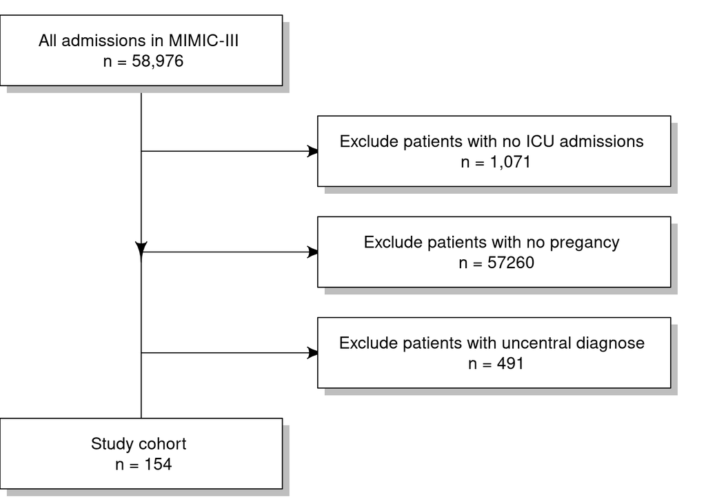

```r
library(shape)
library(diagram)

# set margins and multiplot
par(mfrow = c(1, 1))
par(mar = c(0, 0, 0, 0))

# initialise a plot device
openplotmat()

# position of boxes
# 1st column indicates x axis position between 0 and 1
# 2nd column indicates y axis position between 0 and 1
# automatically assigns vertical position
num_of_boxes <- 5
auto_coords = coordinates(num_of_boxes)
vert_pos = rev(auto_coords[,1])
box_pos <- matrix(nrow = num_of_boxes, ncol = 2, data = 0)
box_pos[1,] = c(0.20, vert_pos[1]) # 1st box
box_pos[2,] = c(0.70, vert_pos[2]) # 2nd box
box_pos[3,] = c(0.70, vert_pos[3]) # 3rd box
box_pos[4,] = c(0.70, vert_pos[4]) # etc...
box_pos[5,] = c(0.20, vert_pos[5])

# content of boxes
box_content <- matrix(nrow = num_of_boxes, ncol = 1, data = 0)
box_content[1] = "All admissions in MIMIC-III \n n = 58,976" # 1st box
box_content[2] = "Exclude patients with no ICU admissions \n n = 1,071" # etc...
box_content[3] = "Exclude patients with no pregancy \n n = 57260"
box_content[4] = "Exclude patients with uncentral diagnose \n n = 491"
box_content[5] = "Study cohort \n n = 154"

# adjust the size of boxes to fit content
box_x <- c(0.20, 0.25, 0.25, 0.25, 0.20)
box_y <- c(0.07, 0.07, 0.07, 0.07, 0.07)

# Draw the arrows
straightarrow(from = c(box_pos[1,1],box_pos[2,2]), to = box_pos[2,], lwd = 1)
straightarrow(from = c(box_pos[1,1],box_pos[3,2]), to = box_pos[3,], lwd = 1)
straightarrow(from = c(box_pos[1,1],box_pos[4,2]), to = box_pos[4,], lwd = 1)
straightarrow(from = box_pos[1,], to = box_pos[5,], lwd = 1)

# Draw the boxes
for (i in 1:num_of_boxes) {
  textrect(mid = box_pos[i,], radx = box_x[i], rady = box_y[i],
           lab = box_content[i],
           shadow.col = "grey")
  }
```

# Data visualization

Now we have a study cohort consisting of pregant patient information. Some patients stay in ICU for more than 5 days and the others do not. Plot each column of the patient information with respect to whether the patient stay in ICU for more than 5 days to get the sense of inherent relationships between them.

Based on each cohort record, the age at admission is treated as a discrete variable. There are similar amounts of patients at full age that stay in ICU for more than 5 days.

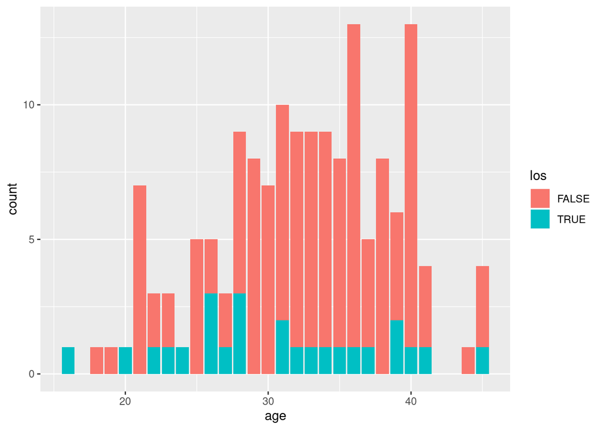

```r
icu_diagnose %>%
  ggplot() +
  geom_bar(mapping = aes(x = age, fill = los))
```

Based on each cohort record, the severity of patients’ ailments is treated as a discrete variable. Patients with severer ailments tend to stay more than 5 days in ICU.

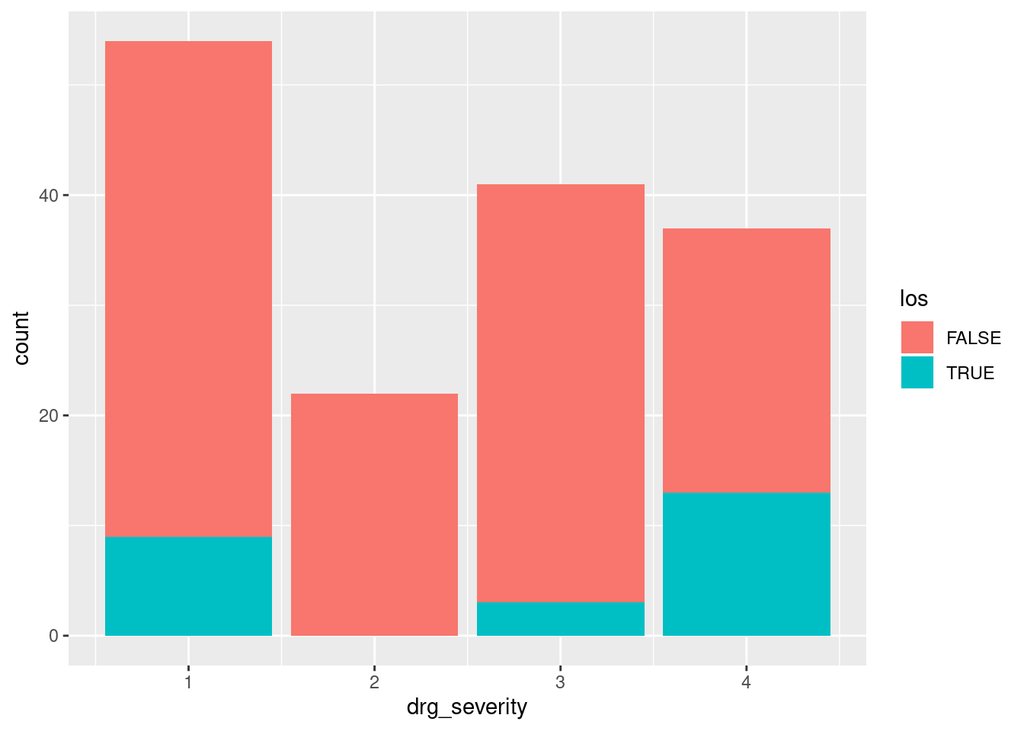

```r
icu_diagnose %>%
  ggplot() +
  geom_bar(mapping = aes(x = drg_severity, fill = los))
```

Based on each cohort record, the ICD-9 code related to complications of pregancy, childbirth, and the puerperium is treated as a discrete variable. Patients with different ICD-9 code have significant difference in whether the length of stay in ICU is more than 5 days or not.

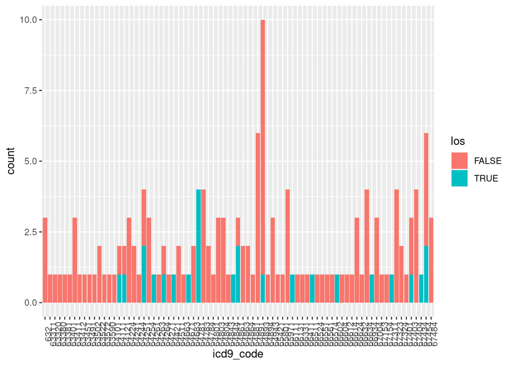

```r
icu_diagnose %>%
  ggplot() +
  geom_bar(mapping = aes(x = icd9_code, fill = los)) +
  theme(axis.text.x = element_text(angle = 90))
```

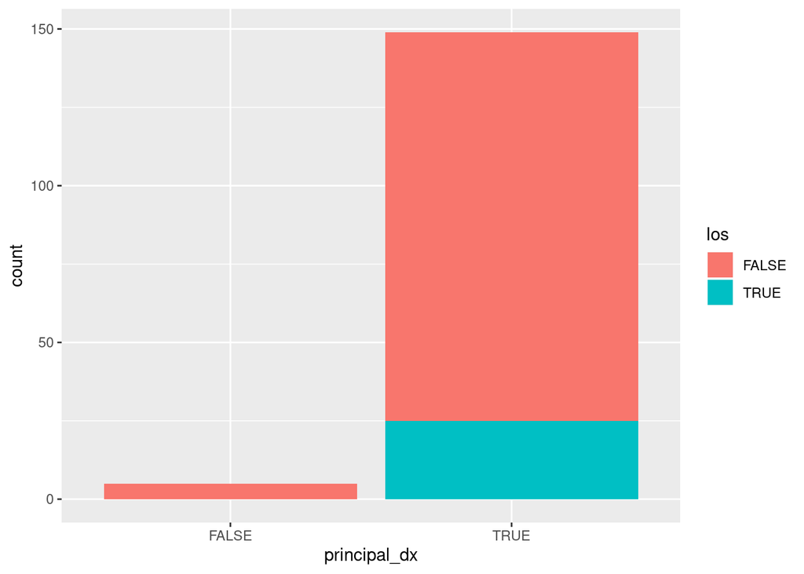

```r
icu_diagnose %>%
  ggplot() +
  geom_bar(mapping = aes(x = principal_dx, fill = los))
```

Based on each cohort record, the ethnicity of patients is treated as a discrete variable. Patients with hispanic ethnicity tend to stay less than 5 days in ICU.

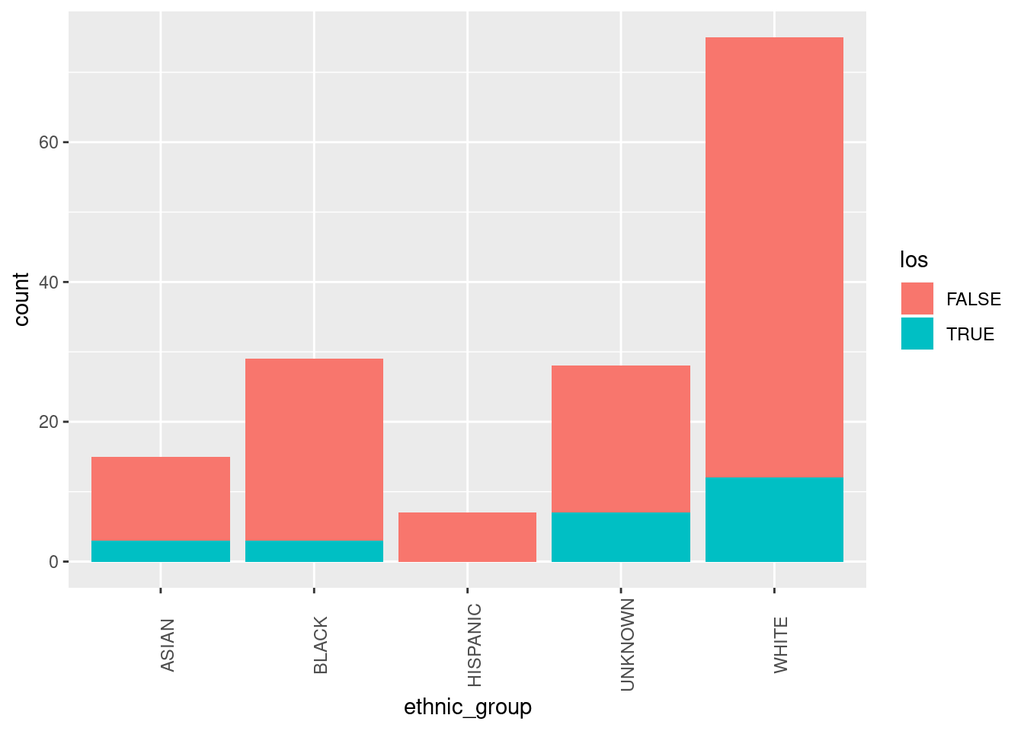

```r
icu_diagnose %>%
  ggplot() +
  geom_bar(mapping = aes(x = ethnic_group, fill = los)) +
  theme(axis.text.x = element_text(angle = 90))
```

# Analytics

Let’s further manipulate the study cohort such that all the variables are type of numerial values between 0 and 1.

```r
icu_diagnose %>%
  mutate(los = ifelse(los, 1, 0)) %>%
  mutate(principal_dx = ifelse(principal_dx, 1, 0)) %>%
  mutate(ethnic_group = case_when(
    str_detect(ethnic_group, "ASIAN") ~ 1,
    str_detect(ethnic_group, "BLACK") ~ 2,
    str_detect(ethnic_group, "HISPANIC") ~ 3,
    str_detect(ethnic_group, "WHITE") ~ 4,
    str_detect(ethnic_group, "UNKNOWN") ~ 5
  )) %>%
  select(age, drg_severity, icd9_code, principal_dx, ethnic_group, los) %>%
  mutate(age = age / 45.0) %>%
  mutate(drg_severity = drg_severity / 4) %>%
  mutate(icd9_code = as.numeric(icd9_code) / 68000) %>%
  mutate(ethnic_group = ethnic_group / 5) %>%
  print() -> raw_data0
```

```
## # Source:   lazy query [?? x 6]
## # Database: postgres 11.0.7 [postgres@/var/run/postgresql:5432/mimic]
##      age drg_severity icd9_code principal_dx ethnic_group   los
##    <dbl>        <dbl>     <dbl>        <dbl>        <dbl> <dbl>
##  1 0.756         0.75   0.954              1          0.6     0
##  2 1             0.5    0.992              1          0.8     0
##  3 0.822         0.25   0.980              1          0.2     0
##  4 0.711         0.25   0.992              1          0.8     1
##  5 0.889         0.25   0.935              1          0.8     0
##  6 0.778         0.25   0.990              1          0.8     0
##  7 0.733         0.25   0.00929            1          0.8     0
##  8 0.511         0.5    0.979              1          0.8     0
##  9 0.8           0.25   0.931              1          0.8     0
## 10 0.4           0.25   0.953              1          0.8     0
## # … with more rows
```

```r
raw_data <- as.data.frame(raw_data0) %>%
  unname() %>%
  # as.matrix() %>%
  print()
```

```
##
## 1   0.7555556 0.75 0.953882353 1 0.6 0
## 2   1.0000000 0.50 0.991970588 1 0.8 0
## 3   0.8222222 0.25 0.979882353 1 0.2 0
## 4   0.7111111 0.25 0.991970588 1 0.8 1
## 5   0.8888889 0.25 0.935147059 1 0.8 0
## 6   0.7777778 0.25 0.990044118 1 0.8 0
## 7   0.7333333 0.25 0.009294118 1 0.8 0
## 8   0.5111111 0.50 0.978691176 1 0.8 0
## 9   0.8000000 0.25 0.931176471 1 0.8 0
## 10  0.4000000 0.25 0.953000000 1 0.8 0
## 11  0.7555556 1.00 0.945161765 1 0.8 0
## 12  0.8222222 0.25 0.990044118 1 0.4 0
## 13  0.4666667 0.25 0.979764706 1 0.2 0
## 14  1.0000000 0.25 0.944867647 1 0.8 0
```

[output cut: 140 more lines]

```r
x_train <- raw_data[1:130, 1:5] %>% print()
```

```
##
## 1   0.7555556 0.75 0.953882353 1 0.6
## 2   1.0000000 0.50 0.991970588 1 0.8
## 3   0.8222222 0.25 0.979882353 1 0.2
## 4   0.7111111 0.25 0.991970588 1 0.8
## 5   0.8888889 0.25 0.935147059 1 0.8
## 6   0.7777778 0.25 0.990044118 1 0.8
## 7   0.7333333 0.25 0.009294118 1 0.8
## 8   0.5111111 0.50 0.978691176 1 0.8
## 9   0.8000000 0.25 0.931176471 1 0.8
## 10  0.4000000 0.25 0.953000000 1 0.8
## 11  0.7555556 1.00 0.945161765 1 0.8
## 12  0.8222222 0.25 0.990044118 1 0.4
## 13  0.4666667 0.25 0.979764706 1 0.2
## 14  1.0000000 0.25 0.944867647 1 0.8
```

[output cut: 116 more lines]

```r
y_train <- raw_data[1:130, 6] %>% print()
```

```
##
## 1   0
## 2   0
## 3   0
## 4   1
## 5   0
## 6   0
## 7   0
## 8   0
## 9   0
## 10  0
## 11  0
## 12  0
## 13  0
## 14  0
```

[output cut: 116 more lines]

```r
dim(x_train)
```

```
## [1] 130   5
```

```r
dim(y_train)
```

```
## [1] 130   1
```

```r
x_test <- raw_data[131:154, 1:5] %>% print()
```

```
##
## 131 0.4888889 1.00 0.9526912 1 0.6
## 132 0.6666667 0.50 0.9543088 1 0.4
## 133 0.8888889 1.00 0.9543088 1 0.8
## 134 0.7111111 0.50 0.9486912 1 0.8
## 135 0.9111111 1.00 0.9912206 1 1.0
## 136 0.5555556 0.75 0.9924118 1 0.8
## 137 0.7333333 0.50 0.9550441 1 0.8
## 138 0.4666667 1.00 0.9535735 1 1.0
## 139 0.7555556 0.75 0.9543088 1 0.8
## 140 0.6666667 1.00 0.9542794 1 0.8
## 141 0.7555556 0.75 0.9900441 1 0.4
## 142 0.5555556 0.75 0.9426618 1 0.2
## 143 0.7111111 0.50 0.9444706 1 0.4
## 144 0.8666667 1.00 0.9450588 1 1.0
## 145 0.8000000 0.75 0.9725147 1 0.2
## 146 0.6888889 1.00 0.9510441 1 0.2
## 147 1.0000000 0.50 0.9538382 1 0.4
## 148 0.6666667 0.75 0.9449118 1 0.4
## 149 0.8666667 1.00 0.9526618 1 0.8
## 150 0.4888889 1.00 0.9535882 1 1.0
## 151 0.8444444 0.75 0.9444706 1 0.4
## 152 0.8888889 0.50 0.9325147 1 1.0
## 153 0.4666667 0.75 0.9543088 1 0.4
## 154 0.6444444 1.00 0.9542794 1 0.4
```

```r
y_test <- raw_data[131:154, 6] %>% print()
```

```
##
## 131 0
## 132 0
## 133 0
## 134 0
## 135 1
## 136 0
## 137 0
## 138 0
## 139 0
## 140 0
## 141 0
## 142 0
## 143 0
## 144 1
## 145 0
## 146 1
## 147 0
## 148 0
## 149 1
## 150 1
## 151 0
## 152 0
## 153 0
## 154 0
```

```r
dim(x_test)
```

```
## [1] 24  5
```

```r
dim(y_test)
```

```
## [1] 24  1
```

```r
# raw_data <- as.vector(raw_data) %>% print()
```

## MNIST-MLP model

Define a sequential model (a linear stack of layers) with 2 fully-connected hidden layers (50 and 25 neurons).

```r
library(keras)
# library(tensorflow)
```

```r
x_train1 <- x_train %>% as.matrix()
y_train1 <- y_train %>% as.matrix()

x_test1 <- x_test %>% as.matrix()
y_test1 <- y_test %>% as.matrix()
```

```r
model1 <- keras_model_sequential()
model1 %>%
  layer_dense(units = 50, activation = 'relu', input_shape = c(5)) %>%
  layer_dropout(rate= 0.4) %>%
  layer_dense(units = 25, activation = 'relu') %>%
  layer_dropout(rate = 0.3) %>%
  layer_dense(units = 5, activation = 'softmax')
summary(model1)
```

```
## Model: "sequential"
## ________________________________________________________________________________
## Layer (type)                        Output Shape                    Param #
## ================================================================================
## dense (Dense)                       (None, 50)                      300
## ________________________________________________________________________________
## dropout (Dropout)                   (None, 50)                      0
## ________________________________________________________________________________
## dense_1 (Dense)                     (None, 25)                      1275
## ________________________________________________________________________________
## dropout_1 (Dropout)                 (None, 25)                      0
## ________________________________________________________________________________
## dense_2 (Dense)                     (None, 5)                       130
## ================================================================================
## Total params: 1,705
## Trainable params: 1,705
## Non-trainable params: 0
## ________________________________________________________________________________
```

Compile the model with appropriate loss function, optimizer, and metrics.

```r
model1 %>% compile(
  loss = 'sparse_categorical_crossentropy',
  optimizer = optimizer_rmsprop(),
  metrics = c('accuracy')
)
```

Trainning and validation.

```r
system.time({
  history <- model1 %>% fit(
    x_train1, y_train1,
    epochs = 30, batch_size = 20,
    validation_split = 0.2
  )
})
```

```
##    user  system elapsed
##   3.089   0.071   4.874
```

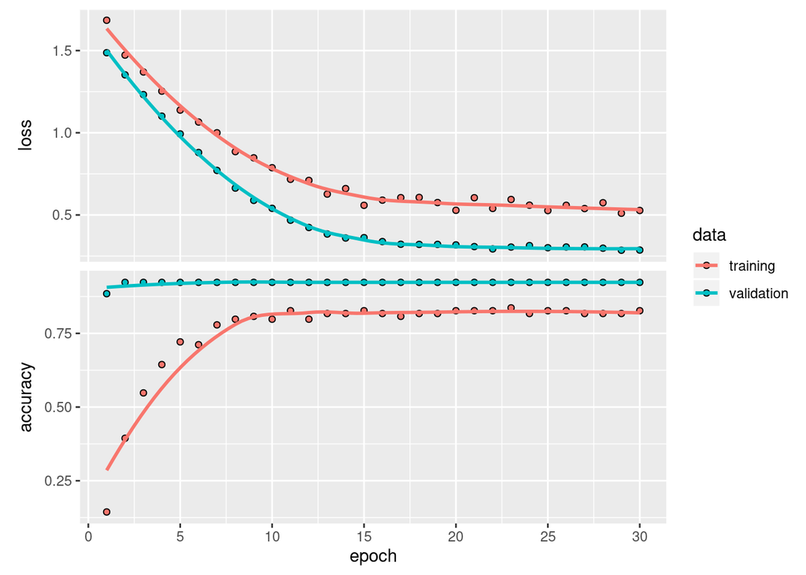

```r
plot(history)
```

Evaluate model performance on the test data.

```r
model1 %>% evaluate(x_test1, y_test1)
```

```
## $loss
## [1] 0.5580696
##
## $accuracy
## [1] 0.7916667
```

## Logistic Regression

Data preparation for logistic regression.

```r
library(aod)
library(ggplot2)
```

```r
raw_data <- as.data.frame(raw_data0) %>%
  select(los, age, drg_severity, icd9_code, principal_dx, ethnic_group) %>%
  print()
```

```
##     los       age drg_severity   icd9_code principal_dx ethnic_group
## 1     0 0.7555556         0.75 0.953882353            1          0.6
## 2     0 1.0000000         0.50 0.991970588            1          0.8
## 3     0 0.8222222         0.25 0.979882353            1          0.2
## 4     1 0.7111111         0.25 0.991970588            1          0.8
## 5     0 0.8888889         0.25 0.935147059            1          0.8
## 6     0 0.7777778         0.25 0.990044118            1          0.8
## 7     0 0.7333333         0.25 0.009294118            1          0.8
## 8     0 0.5111111         0.50 0.978691176            1          0.8
## 9     0 0.8000000         0.25 0.931176471            1          0.8
## 10    0 0.4000000         0.25 0.953000000            1          0.8
## 11    0 0.7555556         1.00 0.945161765            1          0.8
## 12    0 0.8222222         0.25 0.990044118            1          0.4
## 13    0 0.4666667         0.25 0.979764706            1          0.2
## 14    0 1.0000000         0.25 0.944867647            1          0.8
```

[output cut: 140 more lines]

```r
train <- raw_data[1:130, ] %>% as.tibble()%>% print()
```

```
## # A tibble: 130 x 6
##      los   age drg_severity icd9_code principal_dx ethnic_group
##    <dbl> <dbl>        <dbl>     <dbl>        <dbl>        <dbl>
##  1     0 0.756         0.75   0.954              1          0.6
##  2     0 1             0.5    0.992              1          0.8
##  3     0 0.822         0.25   0.980              1          0.2
##  4     1 0.711         0.25   0.992              1          0.8
##  5     0 0.889         0.25   0.935              1          0.8
##  6     0 0.778         0.25   0.990              1          0.8
##  7     0 0.733         0.25   0.00929            1          0.8
##  8     0 0.511         0.5    0.979              1          0.8
##  9     0 0.8           0.25   0.931              1          0.8
## 10     0 0.4           0.25   0.953              1          0.8
## # … with 120 more rows
```

```r
test <- raw_data[131:154, ] %>% as.tibble() %>% print()
```

```
## # A tibble: 24 x 6
##      los   age drg_severity icd9_code principal_dx ethnic_group
##    <dbl> <dbl>        <dbl>     <dbl>        <dbl>        <dbl>
##  1     0 0.489         1        0.953            1          0.6
##  2     0 0.667         0.5      0.954            1          0.4
##  3     0 0.889         1        0.954            1          0.8
##  4     0 0.711         0.5      0.949            1          0.8
##  5     1 0.911         1        0.991            1          1
##  6     0 0.556         0.75     0.992            1          0.8
##  7     0 0.733         0.5      0.955            1          0.8
##  8     0 0.467         1        0.954            1          1
##  9     0 0.756         0.75     0.954            1          0.8
## 10     0 0.667         1        0.954            1          0.8
## # … with 14 more rows
```

```r
#   merge(y_train, x_train)
# names(train)[1] <- "los"
# train %>% print()
#   merge(y_test, x_test)
# names(test)[1] <- "los"
# test %>% print()
```

```r
summary(train)
```

```
##       los              age          drg_severity      icd9_code
##  Min.   :0.0000   Min.   :0.3556   Min.   :0.2500   Min.   :0.009294
##  1st Qu.:0.0000   1st Qu.:0.6222   1st Qu.:0.2500   1st Qu.:0.945022
##  Median :0.0000   Median :0.7333   Median :0.5000   Median :0.954279
##  Mean   :0.1538   Mean   :0.7214   Mean   :0.5635   Mean   :0.940435
##  3rd Qu.:0.0000   3rd Qu.:0.8222   3rd Qu.:0.7500   3rd Qu.:0.979853
##  Max.   :1.0000   Max.   :1.0000   Max.   :1.0000   Max.   :0.992412
##   principal_dx     ethnic_group
##  Min.   :0.0000   Min.   :0.2000
##  1st Qu.:1.0000   1st Qu.:0.4500
##  Median :1.0000   Median :0.8000
##  Mean   :0.9615   Mean   :0.7062
##  3rd Qu.:1.0000   3rd Qu.:0.8000
##  Max.   :1.0000   Max.   :1.0000
```

```r
sapply(train, sd)
```

```
##          los          age drg_severity    icd9_code principal_dx ethnic_group
##    0.3621970    0.1363190    0.3006961    0.1449966    0.1930516    0.2442371
```

Define a model with logistic regression.

```r
# train$pricipal_dx <- factor(train$pricipal_dx)
model2 <- glm(los ~ age + drg_severity + icd9_code + principal_dx
              + ethnic_group, data = train, family = "binomial")
summary(model2)
```

```
##
## Call:
## glm(formula = los ~ age + drg_severity + icd9_code + principal_dx +
##     ethnic_group, family = "binomial", data = train)
##
## Deviance Residuals:
##     Min       1Q   Median       3Q      Max
## -0.9829  -0.6089  -0.4962  -0.3858   2.4149
##
## Coefficients:
##               Estimate Std. Error z value Pr(>|z|)
## (Intercept)   -21.1551  1739.1938  -0.012   0.9903
## age            -3.5696     1.7908  -1.993   0.0462 *
## drg_severity    0.7084     0.8354   0.848   0.3965
## icd9_code       5.7974    11.6514   0.498   0.6188
## principal_dx   15.7163  1739.1564   0.009   0.9928
## ethnic_group    0.4184     1.0419   0.402   0.6880
## ---
## Signif. codes:  0 '***' 0.001 '**' 0.01 '*' 0.05 '.' 0.1 ' ' 1
##
## (Dispersion parameter for binomial family taken to be 1)
##
##     Null deviance: 111.62  on 129  degrees of freedom
## Residual deviance: 103.67  on 124  degrees of freedom
## AIC: 115.67
##
## Number of Fisher Scoring iterations: 16
```

Predict the probability that the patient stays in ICU for more than 5 days with test data.

```r
x_test2 <- test %>%
  select(age, drg_severity, icd9_code, principal_dx, ethnic_group)
x_test2$P <- predict(model2, newdata = x_test2, type = "response")
x_test2
```

```
## # A tibble: 24 x 6
##      age drg_severity icd9_code principal_dx ethnic_group     P
##    <dbl>        <dbl>     <dbl>        <dbl>        <dbl> <dbl>
##  1 0.489         1        0.953            1          0.6 0.332
##  2 0.667         0.5      0.954            1          0.4 0.146
##  3 0.889         1        0.954            1          0.8 0.115
##  4 0.711         0.5      0.949            1          0.8 0.143
##  5 0.911         1        0.991            1          1   0.140
##  6 0.556         0.75     0.992            1          0.8 0.310
##  7 0.733         0.5      0.955            1          0.8 0.138
##  8 0.467         1        0.954            1          1   0.389
##  9 0.756         0.75     0.954            1          0.8 0.150
## 10 0.667         1        0.954            1          0.8 0.224
## # … with 14 more rows
```

Calculate the loss of prediction and plot.

```r
y_test2 <- test %>%
  select(los)
names(y_test2)[1] <- "y"
y_predict2 <- x_test2 %>%
  select(P)
names(y_predict2)[1] <- "y"
y <- bind_rows(y_test2, y_predict2)
type1 <- rep(c("test"), 24) %>% as.tibble()
names(type1)[1] <- "type"
type2 <- rep(c("predict"), 24) %>% as.tibble()
names(type2)[1] <- "type"
type <- bind_rows(type1, type2)
eva <- data.frame(rep(seq(from = 1, to = 24), 2), y, type)
names(eva)[1] <- "ind"
# names(eva)[2] <- "y"
# names(eva)[3] <- "type"
eva %>% print()
```

```
##    ind          y    type
## 1    1 0.00000000    test
## 2    2 0.00000000    test
## 3    3 0.00000000    test
## 4    4 0.00000000    test
## 5    5 1.00000000    test
## 6    6 0.00000000    test
## 7    7 0.00000000    test
## 8    8 0.00000000    test
## 9    9 0.00000000    test
## 10  10 0.00000000    test
## 11  11 0.00000000    test
## 12  12 0.00000000    test
## 13  13 0.00000000    test
## 14  14 1.00000000    test
```

[output cut: 34 more lines]

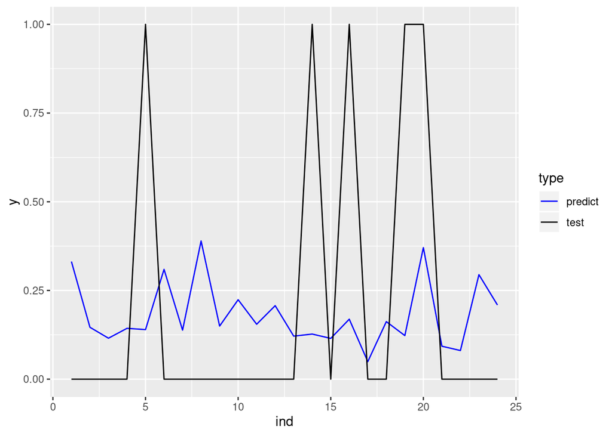

```r
eva %>%
  group_by(type) %>%
  ggplot() +
  geom_line(mapping = aes(x = ind, y = y, color = type), size = 0.5) +
  scale_color_manual(values = c("blue", "black"))
```

```r
# loss <- sqrt(sum((y_test2 - y_predict2)^2) / 24)
loss <- (-1) * sum(y_test2 * log(y_predict2)) / 24
loss
```

```
## [1] 0.3707366
```

Measure how well the model fits by comparing the model with a null model.

```r
with(model2, null.deviance - deviance)
```

```
## [1] 7.957233
```

```r
with(model2, df.null - df.residual)
```

```
## [1] 5
```

```r
with(model2, pchisq(null.deviance - deviance, df.null - df.residual,
                    lower.tail = FALSE))
```

```
## [1] 0.1586084
```

The logistic regression model seems to have lower loss, but since the number of samples is not abundant, and according to the plot shown above, logistic regression gives moderate predict, which actually gives subtle difference among different patients, then this low loss may not be typical.

## Close the connection to a database

Close the connection:

```r
dbDisconnect(con)
```

```
## [1] TRUE
```

# Conclusions

This report analyzes the MIMIC-III data, specifically, information related to patients dignosed complications of pregancy, childbirth, and the puerperium, and admitted into ICU. The study cohort covers the age, ethnicity of patients, the severity of ailments, ICD-9 code, principal or not diagnose information, and the length of stay in ICU. The first 5 variable information is chosen to predict whether a pregant patient stay in ICU for more than 5 days. MNIST-MLP model and logistic regression model are applied to this study cohort. The study cohort is separated into two groups, one as training group and the other as test group. The two models are trained using training group. The predictive performance of the two models is evaluated by the test group. According to the losses of the two models, logistic regression seems to perform better; however, the amount of the samples is very limited, and the logistic regression gives moderate prediction, which may contribute to the low lost, so from this study cohort, we cannot say that logistic regression is better than MNIST-MLP. And since the number of samples is limited, neither of the two models makes accurate enough prediction. Thus, in order to make good prediction, the samples and the model need to be chosen carefully.